# IECD 2C2023: Entrega 1

Nicolás Álvarez, Guido Freire

2023-10-05

```r
muestra <- function(seed, n=200) {
  set.seed(1234)
  binoms <- rbinom(n, size=1, p=0.75)
  return (
    binoms * rnorm(n, mean=0, sd=1)
    + (1 - binoms) * rnorm(n, mean=3.25, sd=sqrt(0.5))
  )
}
```

# Estimación No Paramétrica de la densidad: elección de la ventana

## Selección de ventana $h$ por convalidación cruzada “deje-uno-afuera”

**1, 2, 3, 4.** Nuestra implementación de `bw.loocv` almacena $\hat f_h^{(-i)}(x_i)$ en una matriz `f[i, h]`. Además, recibe el kernel como parámetro opcional `K`, que más adelante nos permite graficar los loglikes para los núcleos Epanechnikov y uniforme.

```r
bw.loocv = function(x, grilla.h = NA, K = dnorm) {
  n <- length(x)
  if (any(is.na(grilla.h))) {
    silverman <- bw.nrd0(x)
    grilla.h <- seq(silverman * 10^(-2), silverman * 10^2, length.out = 100)
  }
  f = matrix(NA, n, length(grilla.h))
  for (i in 1:n) {
    for (h in 1:length(grilla.h)) {
      f[i, h] = sum(K((x[i] - x) / grilla.h[h]))
      f[i,h] <- f[i,h] - K(0)
      f[i,h] <- f[i,h] /  ((n-1)*grilla.h[h])
    }
  }
  loglikes = colMeans(log(f))
  return(list("h.CV" = grilla.h[which.max(loglikes)], "grilla.h" = grilla.h, "loglikes" = loglikes))
}
```

Cargamos los loglikes de cada kernel en un dataframe `data`

```r
x = muestra(1234)

unigauss = bw.loocv(x, seq(0.1, 1, 0.01))
epanechnikov = bw.loocv(x, seq(0.1, 1, 0.01), function(y) ifelse(abs(y) <= 1, 3/4*(1-y^2), 0))
uniforme = bw.loocv(x, seq(0.1, 1, 0.01), function(y) ifelse(abs(y) <= 1, 1/2, 0))

data <- data.frame(grilla = unigauss$grilla.h,
                   gauss = unigauss$loglikes,
                   epanechnikov = epanechnikov$loglikes,
                   uniforme = uniforme$loglikes)
colnames(data) <- c('grilla', 'gauss', 'epanechnikov', 'uniforme')
head(data)
```

```
##   grilla     gauss epanechnikov uniforme
## 1   0.10 -1.807107         -Inf     -Inf
## 2   0.11 -1.797679         -Inf     -Inf
## 3   0.12 -1.790431         -Inf     -Inf
## 4   0.13 -1.784688         -Inf     -Inf
## 5   0.14 -1.780025         -Inf     -Inf
## 6   0.15 -1.776162         -Inf     -Inf
```

Como es logaritmico, tiene sentido que hayan entradas `-Inf` para algunos valores de $h$ pequeños, en los núcleos menos suaves.

**5a.**

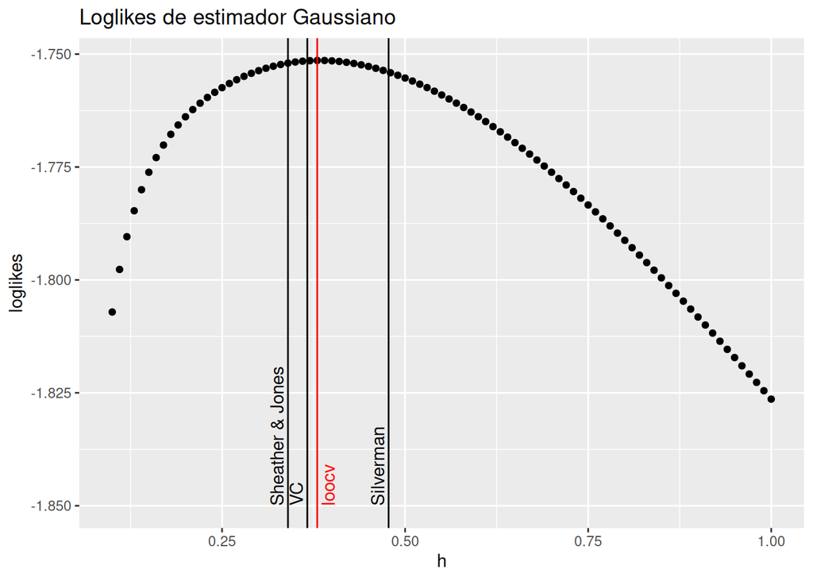

```r
library("ggplot2")
ggplot(data) + geom_point(aes(grilla, gauss)) +
  geom_vline(aes(xintercept = unigauss$h.CV), color = 'red') +
  geom_vline(aes(xintercept = bw.nrd0(x))) +
  geom_vline(aes(xintercept = bw.SJ(x))) +
  geom_vline(aes(xintercept = bw.ucv(x))) + labs(x = 'h', y = 'loglikes') +
  annotate("text", x=unigauss$h.CV+0.015, y=-1.85, label="loocv", angle=90, color = 'red', hjust=0) +
  annotate("text", x=bw.nrd0(x)-0.015, y=-1.85, label="Silverman", angle=90, hjust=0) +
  annotate("text", x=bw.SJ(x)-0.015, y=-1.85, label="Sheather & Jones", angle=90, hjust=0) +
  annotate("text", x=bw.ucv(x)-0.015, y=-1.85, label="VC", angle=90, hjust=0) +
  ggtitle("Loglikes de estimador Gaussiano")
```

Aprovechamos que el kernel es un parámetro para graficar loglikes de cada estimador de núcleo.

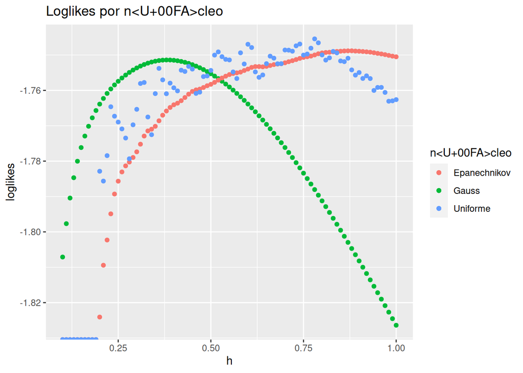

```r
ggplot(data) + geom_point(aes(grilla, gauss, color = 'Gauss')) +
  geom_point(aes(grilla, epanechnikov, color = 'Epanechnikov')) +
  geom_point(aes(grilla, uniforme, color = 'Uniforme')) +
  labs(color='núcleo', x) + ylab("loglikes") + xlab("h") + ggtitle("Loglikes por núcleo")
```

**5b**

nos guardamos cada $h$ y armamos la función de densidad para pasarle a `geom_function` y para cada ventana graficamos:

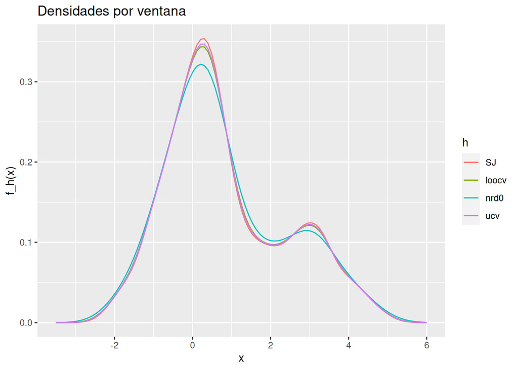

```r
h_loocv = unigauss[[1]]
h_nrd0 = bw.nrd0(x)
h_SJ = bw.SJ(x)
h_ucv = bw.ucv(x)

f_h <- function(y, h) {
  suma <- 0
  for (xi in x) {
    suma <- suma + dnorm((y - xi) / h)
  }
  return(suma/(length(x)*h))
}

# f_h <- function(y, h) return(sum(dnorm((y-x)/h))/(length(x)*h))
# es mucho mas lindo pero ggplot no comulga

ggplot() +
  geom_function(fun = function(x) return(f_h(x, h_loocv)), aes(color = 'loocv')) +
  geom_function(fun = function(x) return(f_h(x, h_nrd0)), aes(color = 'nrd0')) +
  geom_function(fun = function(x) return(f_h(x, h_SJ)), aes(color = 'SJ')) +
  geom_function(fun = function(x) return(f_h(x, h_ucv)), aes(color = 'ucv')) +
  xlim(-3.5,6) + labs(color='h', x) + xlab("x") + ylab("f_h(x)") + ggtitle("Densidades por ventana")
```

## BONUS: Regla de un error estándar

**6.** Declaramos una `bw.loocv_se`, que funciona como la anterior, nada mas que guarda en `SEh.cv` el $SE(\hat l_{h.CV})$ y en `h.nSE` el máximo $h$ que queda por encima de la cantidad de errores estándar.

```r
bw.loocv_se = function(x, grilla.h = NA,n.se, K = dnorm) {
  n <- length(x)
  if (any(is.na(grilla.h))) {
    silverman <- bw.nrd0(x)
    grilla.h <- seq(silverman * 10^(-2), silverman * 10^2, length.out = 100)
  }
  f = matrix(NA, n, length(grilla.h))
  for (i in 1:n) {
    for (h in 1:length(grilla.h)) {
    f[i, h] = sum(K((x[i] - x) / grilla.h[h]))
    f[i,h] <- f[i,h] - K(0)
    f[i,h] <- f[i,h] /  ((n-1)*grilla.h[h])
    }
  }
  loglikes = colMeans(log(f))
  h.CV <- grilla.h[which.max(loglikes)]
  loglikes.se <- apply(f, 2, sd)
  SEh.cv <- loglikes.se[which.max(loglikes)]
  h.nSE <- NA
  for (i in 1:length(grilla.h)) {
    bool <- loglikes[length(grilla.h)+1-i] >= max(loglikes) - n.se*SEh.cv/sqrt(n)
    if (bool) {
      h.nSE <- grilla.h[length(grilla.h)+1-i]
      break
    }
  }
  return(list("h.CV" = h.CV, "grilla.h" = grilla.h, "loglikes" = loglikes, "loglikes.se" = loglikes.se, "h.nSE" = h.nSE, "SEh.cv" = SEh.cv))
}
```

Repetimos el primer gráfico pero con las líneas horizontales de desvio estándar

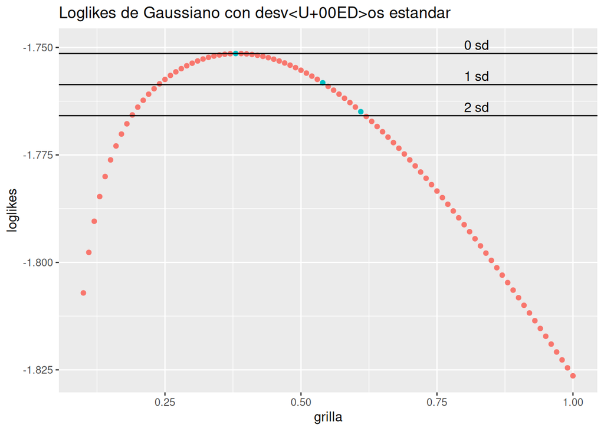

```r
unigaussSE0 <- bw.loocv_se(x, seq(0.1, 1, 0.01), 0)
unigaussSE1 <- bw.loocv_se(x, seq(0.1, 1, 0.01), 1)
unigaussSE2 <- bw.loocv_se(x, seq(0.1, 1, 0.01), 2)

SE0 <- unigaussSE0$loglikes[which(unigaussSE0$grilla.h == unigaussSE0$h.CV)]
SE1 <- unigaussSE1$loglikes[which(unigaussSE1$grilla.h == unigaussSE1$h.CV)]  - unigaussSE1$SEh.cv/sqrt(length(x))
SE2 <- unigaussSE2$loglikes[which(unigaussSE2$grilla.h == unigaussSE2$h.CV)]  - 2*unigaussSE2$SEh.cv/sqrt(length(x))

ggplot(data) + geom_point(aes(grilla, gauss, color = grilla == unigaussSE0$h.nSE | grilla == unigaussSE1$h.nSE | grilla == unigaussSE2$h.nSE)) +
  geom_hline(aes(yintercept = SE0)) +
  geom_hline(aes(yintercept = SE1)) +
  geom_hline(aes(yintercept = SE2)) +
  annotate("text", x=0.8, y=SE0 + 0.002, label="0 sd", hjust=0) +
  annotate("text", x=0.8, y=SE1 + 0.002, label="1 sd", hjust=0) +
  annotate("text", x=0.8, y=SE2 + 0.002, label="2 sd", hjust=0) +
  theme(legend.position = "none") + ggtitle("Loglikes de Gaussiano con desvíos estandar") + ylab("loglikes")
```

Claramente a desvío 0 del máximo esta el máximo, en verde marcamos los $h.nSE$ con $n \in \{0, 1, 2\}$ y en negro las “bandas” de desvío. Respectivamente 0.38, 0.54 y 0.61.

*Referencia: [notas de Tibshirani](https://www.stat.cmu.edu/~ryantibs/datamining/lectures/19-val2-marked.pdf)*